# Supervised learning applied to text

## Naive Bayes

The code here illustrates how we can use supervised machine learning to predict categories for unseen documents based on a set of labeled documents. Our running example will focus on whether we can predict gender based on the character distribution of first names.

The file `data/EN-names.csv` contains a list of nearly 25,000 popular names in the US labeled by the most frequent gender based on Social Security records.

Let’s read this dataset into R, convert it into a corpus with gender as a document-level variable.

```r
library("quanteda", quietly = TRUE, warn.conflicts = FALSE, verbose = FALSE)
d <- read.csv("data/EN-names.csv", stringsAsFactors=FALSE)

# creating corpus object
cnames <- corpus(d, text_field = "name")
docvars(cnames, "gender") <- d$gender
```

As we saw in the lecture, we need to specify what the training set and test set will be. In this case, let’s just take an 80% random sample of names as training set and the rest as test set, which we will use to compute the performance of our model. We will then create a document-feature matrix where each feature is a character.

```r
# shuffling to split into training and test set
smp <- sample(c("train", "test"), size=ndoc(cnames),
                prob=c(0.80, 0.20), replace=TRUE)
train <- which(smp=="train")
test <- which(smp=="test")

# tokenizing and creating DFM
characters <- tokens(cnames, what="character")
namesdfm <- dfm(characters)
```

We’re now ready to train our model! Let’s start with a Naive Bayes model using the `textmodel_nb()` function:

```r
# training Naive Bayes model
nb <- textmodel_nb(namesdfm[train,], docvars(cnames, "gender")[train])
# predicting labels for test set
preds <- predict(nb, newdata = namesdfm[test,])
# computing the confusion matrix
(cm <- table(preds, docvars(cnames, "gender")[test]))
```

```
##
## preds    female male
##   female   2286  661
##   male      834 1190
```

How well did we do? We can compute precision, recall, and accuracy to quantify it.

```r
# function to compute performance metrics
precrecall <- function(mytable, verbose=TRUE) {
    truePositives <- mytable[1,1]
    falsePositives <- sum(mytable[1,]) - truePositives
    falseNegatives <- sum(mytable[,1]) - truePositives
    precision <- truePositives / (truePositives + falsePositives)
    recall <- truePositives / (truePositives + falseNegatives)
    if (verbose) {
        print(mytable)
        cat("\n precision =", round(precision, 2),
            "\n    recall =", round(recall, 2), "\n")
    }
    invisible(c(precision, recall))
}

# precision and recall
precrecall(cm)
```

```
##
## preds    female male
##   female   2286  661
##   male      834 1190
##
##  precision = 0.78
##     recall = 0.73
```

```r
# accuracy
sum(diag(cm)) / sum(cm)
```

```
## [1] 0.6992557
```

Hmm, not terribly great. But what if we try with character n-grams up to trigrams instead of unigrams?

```r
characters <- tokens(cnames, what="character", ngrams=1:3)
namesdfm <- dfm(characters)
# Naive Bayes model
nb <- textmodel_nb(namesdfm[train,], docvars(cnames, "gender")[train])
preds <- predict(nb, newdata = namesdfm[test,])
(cm <- table(preds, docvars(cnames, "gender")[test]))
```

```
##
## preds    female male
##   female   2458  538
##   male      662 1313
```

```r
# performance
precrecall(cm) # precision, recall
```

```
##
## preds    female male
##   female   2458  538
##   male      662 1313
##
##  precision = 0.82
##     recall = 0.79
```

```r
sum(diag(cm)) / sum(cm) # accuracy
```

```
## [1] 0.7585999
```

Slightly better! We can dig a bit more into the model by extracting the posterior class probabilities for specific characters.

```r
# extracting posterior word probabilities
probs <- nb$PcGw
probs[,c("a", "o", "e")]
```

```
##         features
## classes          a         o         e
##   female 0.6036313 0.2738124 0.5297178
##   male   0.3963687 0.7261876 0.4702822
```

```r
# and this is how we would extract the features with the highest and lowest posterior class probabilities
df <- data.frame(
  ngram = colnames(probs),
  prob_female_ngram = probs["female",],
  stringsAsFactors=F)
df <- df[order(df$prob_female_ngram),]

head(df, n=10)
```

```
##       ngram prob_female_ngram
## r_t_o r_t_o        0.01726003
## l_d_o l_d_o        0.02457994
## l_t_o l_t_o        0.02960148
## z_a_c z_a_c        0.02960148
## t_h_o t_h_o        0.03119471
## a_b_d a_b_d        0.03296919
## w_e_s w_e_s        0.03296919
## o_l_t o_l_t        0.03720155
## e_u_s e_u_s        0.03975317
## x_i_m x_i_m        0.03975317
```

```r
tail(df, n=10)
```

```
##       ngram prob_female_ngram
## s_h_l s_h_l         0.9240772
## b_e_t b_e_t         0.9251748
## y_n_n y_n_n         0.9272773
## e_a_h e_a_h         0.9272773
## l_y_n l_y_n         0.9277846
## k_a_t k_a_t         0.9316017
## e_l_y e_l_y         0.9320506
## t_t_a t_t_a         0.9342098
## n_n_a n_n_a         0.9377692
## i_t_l i_t_l         0.9438453
```

## Regularized regression

We’ll now switch to the other type of classifier we just saw in the lecture - a regularized regression. This model is not implemented in quanteda, but we can use one of the other available packages in R. For regularized regression, glmnet is in my opinion the best option, since it tends to be faster than caret or mlr (in my experience at least), and it has cross-validation already built-in, so we don’t need to code it from scratch.

We’ll start with a ridge regression:

```r
# install.packages("glmnet")
library(glmnet)
ridge <- cv.glmnet(x=namesdfm[train,], y=docvars(cnames, "gender")[train],
                   alpha=0, nfolds=5, family="binomial")
```

We use the `cv.glmnet()` function, with the following options: `alpha` indicates whether we want a ridge penalty (`alpha=0`) or a lasso penalty (`alpha=1`), `nfolds` is the number of K folds for the cross-validation procedure, and `family` indicates the type of classifier (`binomial` means binary here).

It’s generally good practice to plot the results of the cross-validation procedure.

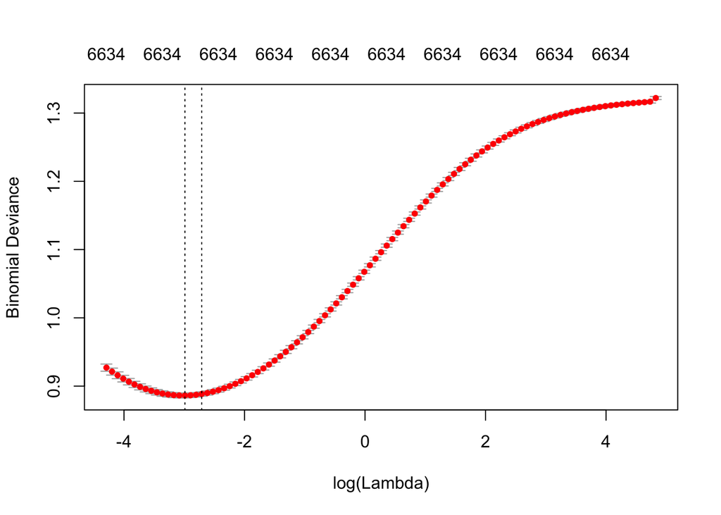

```r
plot(ridge)
```

What do we learn from this plot? It shows the error (with confidence intervals based on the cross-validation procedure) for each possible value of lambda (the penalty parameter). The numbers on top indicate the number of features (which remain constant with ridge, unlike with lasso). We generally find that increasing the penalty parameter actually hurts.

Let’s now compute different performance metrics to see how we’re doing now.

```r
pred <- predict(ridge, namesdfm[test,], type="class")
(cm <- table(pred, docvars(cnames, "gender")[test]))
```

```
##
## pred     female male
##   female   2760  617
##   male      360 1234
```

```r
# performance metrics
precrecall(cm) # precision, recall
```

```
##
## pred     female male
##   female   2760  617
##   male      360 1234
##
##  precision = 0.82
##     recall = 0.88
```

```r
sum(diag(cm)) / sum(cm) # accuracy
```

```
## [1] 0.8034601
```

Not bad! And with a regularized regression, in a similar way as we did earlier with the Naive Bayes model, we can also extract the feature-specific coefficients to try to understand how the latent dimension we’re capturing here can be interpret.

```r
# extracting coefficients
best.lambda <- which(ridge$lambda==ridge$lambda.1se)
beta <- ridge$glmnet.fit$beta[,best.lambda]

## identifying predictive features
df <- data.frame(coef = as.numeric(beta),
                ngram = names(beta), stringsAsFactors=F)

# lowest and highest coefficients
df <- df[order(df$coef),]
head(df[,c("coef", "ngram")], n=10)
```

```
##           coef ngram
## 6924 -3.719384 g_s_a
## 3850 -3.567915 r_w_o
## 4841 -3.481270 g_o_c
## 3394 -3.404506 l_u_v
## 5039 -3.326285 d_'_j
## 4805 -3.286025 y_b_o
## 5317 -3.226952 p_r_u
## 6396 -3.201766 -_y_i
## 4545 -3.100169 v_e_i
## 4420 -3.058348 p_e_i
```

```r
tail(df[,c("coef", "ngram")], n=10)
```

```
##          coef ngram
## 2060 3.113204 x_e_y
## 6504 3.151422 n_j_h
## 478  3.203879 z_u_y
## 2091 3.209531 x_i_z
## 6002 3.299733 f_l_e
## 5608 3.478695 d_o_i
## 6270 3.523904 t_'_s
## 6221 3.648734 r_m_p
## 6551 3.684610 e_g_w
## 6926 3.872200 k_a_-
```

Finally, the code below shows how to re-run the analysis but this time with lasso. Note that this time the number of features will change depending on the value of the penalty parameter.

```r
# now with lasso
lasso <- cv.glmnet(x=namesdfm[train,], y=docvars(cnames, "gender")[train],
                   alpha=1, nfolds=5, family="binomial")
```

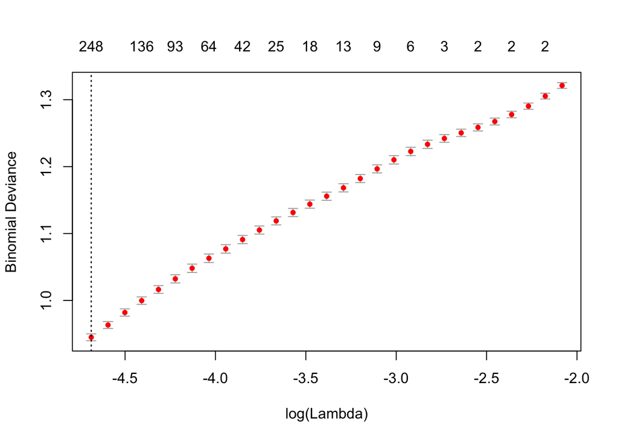

```r
plot(lasso)
```

```r
pred <- predict(lasso, namesdfm[test,], type="class")
(cm <- table(pred, docvars(cnames, "gender")[test]))
```

```
##
## pred     female male
##   female   2764  755
##   male      356 1096
```

```r
# precision and recall
precrecall(cm)
```

```
##
## pred     female male
##   female   2764  755
##   male      356 1096
##
##  precision = 0.79
##     recall = 0.89
```

```r
# accuracy
sum(diag(cm)) / sum(cm)
```

```
## [1] 0.7765037
```

```r
# extracting coefficients
best.lambda <- which(lasso$lambda==lasso$lambda.1se)
beta <- lasso$glmnet.fit$beta[,best.lambda]

## identifying predictive features
df <- data.frame(coef = as.numeric(beta),
                ngram = names(beta), stringsAsFactors=F)

# note that some features become 0
table(df$coef==0)
```

```
##
## FALSE  TRUE
##   248  6795
```

```r
df <- df[order(df$coef),]
head(df[,c("coef", "ngram")], n=10)
```

```
##            coef ngram
## 644  -1.1479236 r_s_t
## 53   -1.0394946   n_a
## 215  -1.0023482   l_y
## 4606 -0.9670056 h_u_o
## 5    -0.9607247     a
## 2378 -0.8685197 r_t_n
## 1215 -0.8143534 o_r_a
## 52   -0.7777855   n_n
## 64   -0.7496050   n_e
## 161  -0.7182819 x_u_s
```

```r
tail(df[,c("coef", "ngram")], n=10)
```

```
##           coef ngram
## 777  0.8698421 t_h_o
## 5261 0.8926605 l_i_p
## 18   0.8945551   a_a
## 3305 0.9114631 a_r_q
## 3026 0.9834749 a_t_n
## 2985 1.1515681 m_a_x
## 656  1.1731534 b_e_n
## 1713 1.2764675 n_a_t
## 491  1.4311799 a_b_d
## 6394 2.3320093 z_a_c
```